# Regression Models

*This note is a reorganization of Dr. Brian Caffo's lecture notes for the Coursera course [Regression Models](https://class.coursera.org/regmods-002).*

# Module III : Generalized Linear Models

## Introduction

The Generalized Linear Model (GLM) was introduced in a 1972 RSSB paper by Nelder and Wedderburn. It involves three components

- An *exponential family* model for the response.
- A systematic component via a linear predictor.
- A link function that connects the means of the response to the linear predictor.

> GLMs can be thought of as a two-stage modeling approach. We first model the response variable using a probability distribution, such as the binomial or Poisson distribution. Second, we model the parameter of the distribution using a collection of prediction and a special form of multi regression. - [OpenIntro](http://www.openintro.org)

Mathematically, first we assume that \( Y_i \sim N(\mu_i, \sigma^2) \) (the Gaussian distribution is an exponential family distribution) and define the linear predictor to be \( \eta_i = \sum_{k=1}^p X_{ik} \beta_k \). The link function is \( g(\mu) = \eta \).

For linear models \( g(\mu) = \mu \) so that \( \mu_i = \eta_i \). This yields the same likelihood model as our additive error Gaussian linear model \( Y_i = \sum_{k=1}^p X_{ik} \beta_k + \epsilon_{i} \) where \( \epsilon_i \stackrel{iid}{\sim} N(0, \sigma^2) \).

### Logistic Regression

logistic regression is a type of GLM where regular multiple regression does not work well. Assume that \( Y_i \sim Bernoulli(\mu_i) \) so that \( E[Y_i] = \mu_i \) where \( 0\leq \mu_i \leq 1 \).

- Linear predictor \( \eta_i = \sum_{k=1}^p X_{ik} \beta_k \)
- Link function \( g(\mu) = \eta = \log\left( \frac{\mu}{1 - \mu}\right) \) \( g \) is the (natural) log odds, referred to as the **logit**. For a probability p, the function \( p/(1 − p) \) is called the **odds ratio**.
- Note then we can invert the logit function as \[ \mu_i = \frac{\exp(\eta_i)}{1 + \exp(\eta_i)} ~~~\mbox{and}~~~ 1 - \mu_i = \frac{1}{1 + \exp(\eta_i)} \] Thus the likelihood is \[ \prod_{i=1}^n \mu_i^{y_i} (1 - \mu_i)^{1-y_i} = \exp\left(\sum_{i=1}^n y_i \eta_i \right) \prod_{i=1}^n (1 + \eta_i)^{-1} \]

### Poisson Regression

Assume that \( Y_i \sim Poisson(\mu_i) \) so that \( E[Y_i] = \mu_i \) where \( 0\leq \mu_i \)

- Linear predictor \( \eta_i = \sum_{k=1}^p X_{ik} \beta_k \)
- Link function \( g(\mu) = \eta = \log(\mu) \)
- Recall that \( e^x \) is the inverse of \( \log(x) \) so that \[ \mu_i = e^{\eta_i} \] Thus, the likelihood is \[ \prod_{i=1}^n (y_i !)^{-1} \mu_i^{y_i}e^{-\mu_i} \propto \exp\left(\sum_{i=1}^n y_i \eta_i - \sum_{i=1}^n \mu_i\right) \]

### Summary

In each case, the only way in which the likelihood depends on the data is through \[ \sum_{i=1}^n y_i \eta_i = \sum_{i=1}^n y_i\sum_{k=1}^p X_{ik} \beta_k = \sum_{k=1}^p \beta_k\sum_{i=1}^n X_{ik} y_i \] Thus if we don't need the full data, only \( \sum_{i=1}^n X_{ik} y_i \). This simplification is a consequence of chosing so-called **canonical** link functions.

All models acheive their maximum at the root of the so called normal equations \[ 0=\sum_{i=1}^n \frac{(Y_i - \mu_i)}{Var(Y_i)}W_i \] where \( W_i \) are the derivative of the inverse of the link function.

The variances in the GLMs are

- For the linear model \( Var(Y_i) = \sigma^2 \) is constant.
- For Bernoulli case \( Var(Y_i) = \mu_i (1 - \mu_i) \)
- For the Poisson case \( Var(Y_i) = \mu_i \).
- In the latter cases, it is often relevant to have a more flexible variance model, even if it doesn't correspond to an actual likelihood \[ 0=\sum_{i=1}^n \frac{(Y_i - \mu_i)}{\phi \mu_i (1 - \mu_i ) } W_i ~~~\mbox{and}~~~ 0=\sum_{i=1}^n \frac{(Y_i - \mu_i)}{\phi \mu_i} W_i \]
- These are called **quasi-likelihood** normal equations

### Odds and ends

- The normal equations have to be solved iteratively. Resulting in \( \hat \beta_k \) and, if included, \( \hat \phi \).
- Predicted linear predictor responses can be obtained as \( \hat \eta = \sum_{k=1}^p X_k \hat \beta_k \)
- Predicted mean responses as \( \hat \mu = g^{-1}(\hat \eta) \)
- Coefficients are interpretted as \[ g(E[Y | X_k = x_k + 1, X_{\sim k} = x_{\sim k}]) - g(E[Y | X_k = x_k, X_{\sim k}=x_{\sim k}]) = \beta_k \] or the change in the link function of the expected response per unit change in \( X_k \) holding other regressors constant.
- Variations on Newon/Raphson's algorithm are used to do it.
- Asymptotics are used for inference usually.
- Many of the ideas from linear models can be brought over to GLMs.

## Logistic Regression

In this section, we will explore the Baltimore Ravens data. First let's load it and check its structure

```r
download.file("https://dl.dropboxusercontent.com/u/7710864/data/ravensData.rda",
    destfile = "../03_02_binaryOutcomes/data/ravensData.rda", method = "wget")
load("../03_02_binaryOutcomes/data/ravensData.rda")
head(ravensData)
```

```
##   ravenWinNum ravenWin ravenScore opponentScore
## 1           1        W         24             9
## 2           1        W         38            35
## 3           1        W         28            13
## 4           1        W         34            31
## 5           1        W         44            13
## 6           0        L         23            24
```

```r
str(ravensData)
```

```
## 'data.frame':    20 obs. of  4 variables:
##  $ ravenWinNum  : num  1 1 1 1 1 0 1 1 1 1 ...
##  $ ravenWin     : Factor w/ 2 levels "L","W": 2 2 2 2 2 1 2 2 2 2 ...
##  $ ravenScore   : num  24 38 28 34 44 23 31 23 9 31 ...
##  $ opponentScore: num  9 35 13 31 13 24 30 16 6 29 ...
```

### Linear Regression

The linear regression can be modeled as \[ RW_i = b_0 + b_1 RS_i + e_i \] Where

- \( RW_i \) - 1 if a Ravens win, 0 if not
- \( RS_i \) - Number of points Ravens scored
- \( b_0 \) - probability of a Ravens win if they score 0 points
- \( b_1 \) - increase in probability of a Ravens win for each additional point
- \( e_i \) - residual variation due

```r
lmRavens <- lm(ravensData$ravenWinNum ~ ravensData$ravenScore)
summary(lmRavens)$coef
```

```
##                       Estimate Std. Error t value Pr(>|t|)
## (Intercept)             0.2850   0.256643   1.111  0.28135
## ravensData$ravenScore   0.0159   0.009059   1.755  0.09625
```

### Odds

**Binary Outcome 0/1**

\[ RW_i \]

**Probability (0,1)**

\[ \rm{Pr}(RW_i | RS_i, b_0, b_1 ) \]

**Odds $(0,\infty)$** \[ \frac{\rm{Pr}(RW_i | RS_i, b_0, b_1 )}{1-\rm{Pr}(RW_i | RS_i, b_0, b_1)} \]

**Log odds $(-\infty,\infty)$**

\[ \log\left(\frac{\rm{Pr}(RW_i | RS_i, b_0, b_1 )}{1-\rm{Pr}(RW_i | RS_i, b_0, b_1)}\right) \]

### Linear vs. logistic regression

**Linear**

\[ RW_i = b_0 + b_1 RS_i + e_i \]

or

\[ E[RW_i | RS_i, b_0, b_1] = b_0 + b_1 RS_i \]

**Logistic**

\[ \rm{Pr}(RW_i | RS_i, b_0, b_1) = \frac{\exp(b_0 + b_1 RS_i)}{1 + \exp(b_0 + b_1 RS_i)} \]

or

\[ \log\left(\frac{\rm{Pr}(RW_i | RS_i, b_0, b_1 )}{1-\rm{Pr}(RW_i | RS_i, b_0, b_1)}\right) = b_0 + b_1 RS_i \]

### Logistic Regression

\[ \log\left(\frac{\rm{Pr}(RW_i | RS_i, b_0, b_1 )}{1-\rm{Pr}(RW_i | RS_i, b_0, b_1)}\right) = b_0 + b_1 RS_i \]

- \( b_0 \) - Log odds of a Ravens win if they score zero points
- \( b_1 \) - Log odds ratio of win probability for each point scored (compared to zero points)
- \( \exp(b_1) \) - **Odds ratio** of win probability for each point scored (compared to zero points)

### Odds

- Imagine that you are playing a game where you flip a coin with success probability \( p \).
- If it comes up heads, you win \( X \). If it comes up tails, you lose \( Y \).
- What should we set \( X \) and \( Y \) for the game to be fair?

  $$E[earnings]= X p - Y (1 - p) = 0$$
- Implies \[ \frac{Y}{X} = \frac{p}{1 - p} \]
- The odds can be said as “How much should you be willing to pay for a \( p \) probability of winning a dollar?”
  - (If \( p > 0.5 \) you have to pay more if you lose than you get if you win.)
  - (If \( p < 0.5 \) you have to pay less if you lose than you get if you win.)

```r
logRegRavens <- glm(ravensData$ravenWinNum ~ ravensData$ravenScore, family = "binomial")
summary(logRegRavens)
```

```
##
## Call:
## glm(formula = ravensData$ravenWinNum ~ ravensData$ravenScore,
##     family = "binomial")
##
## Deviance Residuals:
##    Min      1Q  Median      3Q     Max
## -1.758  -1.100   0.530   0.806   1.495
##
## Coefficients:
##                       Estimate Std. Error z value Pr(>|z|)
## (Intercept)            -1.6800     1.5541   -1.08     0.28
## ravensData$ravenScore   0.1066     0.0667    1.60     0.11
##
## (Dispersion parameter for binomial family taken to be 1)
##
##     Null deviance: 24.435  on 19  degrees of freedom
## Residual deviance: 20.895  on 18  degrees of freedom
## AIC: 24.89
##
## Number of Fisher Scoring iterations: 5
```

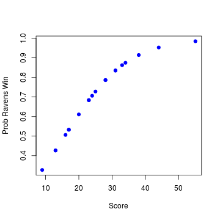

```r
plot(ravensData$ravenScore, logRegRavens$fitted, pch = 19, col = "blue", xlab = "Score",
    ylab = "Prob Ravens Win")
```

**Odds ratios and confidence intervals**

```r
exp(logRegRavens$coeff)
```

```
##           (Intercept) ravensData$ravenScore
##                0.1864                1.1125
```

```r
exp(confint(logRegRavens))
```

```
##                          2.5 % 97.5 %
## (Intercept)           0.005675  3.106
## ravensData$ravenScore 0.996230  1.303
```

**ANOVA for logistic regression**

```r
anova(logRegRavens, test = "Chisq")
```

```
## Analysis of Deviance Table
##
## Model: binomial, link: logit
##
## Response: ravensData$ravenWinNum
##
## Terms added sequentially (first to last)
##
##
##                       Df Deviance Resid. Df Resid. Dev Pr(>Chi)
## NULL                                     19       24.4
## ravensData$ravenScore  1     3.54        18       20.9     0.06 .
## ---
## Signif. codes:  0 '***' 0.001 '**' 0.01 '*' 0.05 '.' 0.1 ' ' 1
```

We can interpreting odds ratios

- Not probabilities
- Odds ratio of 1 = no difference in odds
- Log odds ratio of 0 = no difference in odds
- Odds ratio < 0.5 or > 2 commonly a “moderate effect”
- Relative risk \( \frac{\rm{Pr}(RW_i | RS_i = 10)}{\rm{Pr}(RW_i | RS_i = 0)} \) often easier to interpret, harder to estimate
- For small probabilities RR \( \approx \) OR but **they are not the same**!

## Poisson Regression

There are many data taking the form of **counts**, such as the number of calls to a call center, the number of flu cases in an area, the number of cars that cross a bridge and etc. The data may also be in the form of **rates**, such as the percentage of children passing a test or the percentage of hits to a website from a country.

In all the above cases, Linear regression with transformation is an option.

First, we recall that the Poisson distribution is a useful model for counts and rates (rate is count per some monitoring time). Some examples uses of the Poisson distribution

- Modeling web traffic hits
- Incidence rates
- Approximating binomial probabilities with small \( p \) and large \( n \)
- Analyzing contigency table data

For the Poisson distribution

- \( X \sim Poisson(t\lambda) \) if \[ P(X = x) = \frac{(t\lambda)^x e^{-t\lambda}}{x!} \] For \( x = 0, 1, \ldots \).
- The mean of the Poisson is \( E[X] = t\lambda \), thus \( E[X / t] = \lambda \)
- The variance of the Poisson is \( Var(X) = t\lambda \).
- The Poisson tends to a normal as \( t\lambda \) gets large.

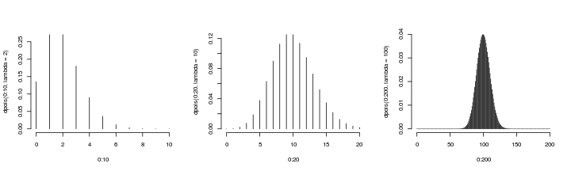

```r
par(mfrow = c(1, 3))
plot(0:10, dpois(0:10, lambda = 2), type = "h", frame = FALSE)
plot(0:20, dpois(0:20, lambda = 10), type = "h", frame = FALSE)
plot(0:200, dpois(0:200, lambda = 100), type = "h", frame = FALSE)
```

We can show the the mean and variance of a poisson distribution are equal

```r
x <- 0:10000
lambda = 3
mu <- sum(x * dpois(x, lambda = lambda))
sigmasq <- sum((x - mu)^2 * dpois(x, lambda = lambda))
c(mu, sigmasq)
```

```
## [1] 3 3
```

### Example: Leek Group Website Traffic

As an example, let's consider the daily counts to [Jeff Leek's website](http://biostat.jhsph.edu/%7Ejleek/), since the unit of time is always one day, set \( t = 1 \) and then the Poisson mean is interpretted as web hits per day. (If we set \( t = 24 \), it would be web hits per hour). (http://skardhamar.github.com/rga/)

```r
download.file("https://dl.dropboxusercontent.com/u/7710864/data/gaData.rda",
    destfile = "../03_03_countOutcomes/data/gaData.rda", method = "wget")
load("../03_03_countOutcomes/data/gaData.rda")
gaData$julian <- julian(gaData$date)
str(gaData)
```

```
## 'data.frame':    731 obs. of  4 variables:
##  $ date       : Date, format: "2011-01-01" "2011-01-02" ...
##  $ visits     : num  0 0 0 0 0 0 0 0 0 0 ...
##  $ simplystats: num  0 0 0 0 0 0 0 0 0 0 ...
##  $ julian     : atomic  14975 14976 14977 14978 14979 ...
##   ..- attr(*, "origin")= Date, format: "1970-01-01"
```

If we fit the data with a simple linear regression model

\[ NH_i = b_0 + b_1 JD_i + e_i \]

- \( NH_i \) - number of hits to the website
- \( JD_i \) - day of the year (Julian day)
- \( b_0 \) - number of hits on Julian day 0 (1970-01-01)
- \( b_1 \) - increase in number of hits per unit day
- \( e_i \) - variation due to everything we didn't measure

We can also plot the Linear regression line

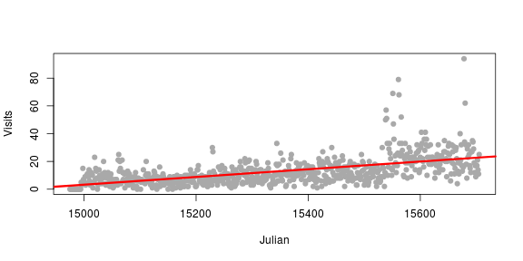

```r
plot(gaData$julian, gaData$visits, pch = 19, col = "darkgrey", xlab = "Julian",
    ylab = "Visits")
lm1 <- lm(gaData$visits ~ gaData$julian)
abline(lm1, col = "red", lwd = 3)
```

Aside, Let's take the natural log of the outcome has a specific interpretation. Consider the model

\[ \log(NH_i) = b_0 + b_1 JD_i + e_i \]

- \( NH_i \) - number of hits to the website
- \( JD_i \) - day of the year (Julian day)
- \( b_0 \) - log number of hits on Julian day 0 (1970-01-01)
- \( b_1 \) - increase in log number of hits per unit day
- \( e_i \) - variation due to everything we didn't measure

To exponentiate coefficients

- \( e^{E[\log(Y)]} \) geometric mean of \( Y \).
  - With no covariates, this is estimated by \( e^{\frac{1}{n}\sum_{i=1}^n \log(y_i)} = (\prod_{i=1}^n y_i)^{1/n} \)
- When you take the natural log of outcomes and fit a regression model, your exponentiated coefficients estimate things about geometric means.
- \( e^{\beta_0} \) estimated geometric mean hits on day 0
- \( e^{\beta_1} \) estimated relative increase or decrease in geometric mean hits per day
- There's a problem with logs with you have zero counts, adding a constant works

```r
round(exp(coef(lm(I(log(gaData$visits + 1)) ~ gaData$julian))), 5)
```

```
##   (Intercept) gaData$julian
##         0.000         1.002
```

### Linear vs. Poisson regression

**Linear**

\[ NH_i = b_0 + b_1 JD_i + e_i \]

or

\[ E[NH_i | JD_i, b_0, b_1] = b_0 + b_1 JD_i \]

**Poisson/log-linear**

\[ \log\left(E[NH_i | JD_i, b_0, b_1]\right) = b_0 + b_1 JD_i \]

or

\[ E[NH_i | JD_i, b_0, b_1] = \exp\left(b_0 + b_1 JD_i\right) \]

**Multiplicative differences** \[ E[NH_i | JD_i, b_0, b_1] = \exp\left(b_0 + b_1 JD_i\right) \] \[ E[NH_i | JD_i, b_0, b_1] = \exp\left(b_0 \right)\exp\left(b_1 JD_i\right) \]

If \( JD_i \) is increased by one unit, \( E[NH_i | JD_i, b_0, b_1] \) is multiplied by \( \exp\left(b_1\right) \)

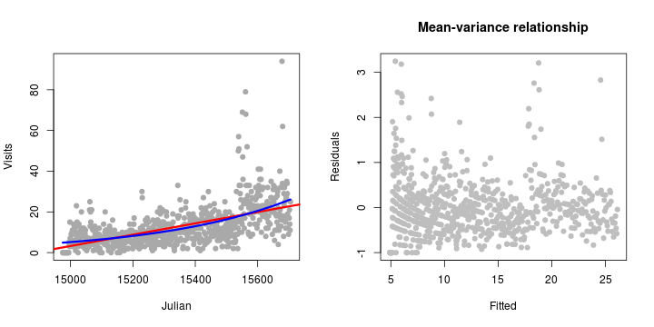

```r
par(mfrow = c(1, 2))
plot(gaData$julian, gaData$visits, pch = 19, col = "darkgrey", xlab = "Julian",
    ylab = "Visits")
glm1 <- glm(gaData$visits ~ gaData$julian, family = "poisson")
abline(lm1, col = "red", lwd = 3)
lines(gaData$julian, glm1$fitted, col = "blue", lwd = 3)
plot(glm1$fitted, glm1$residuals, pch = 19, col = "grey", ylab = "Residuals",
    xlab = "Fitted", main = "Mean-variance relationship")
```

### Model agnostic standard errors

```r
library(sandwich)
confint.agnostic <- function(object, parm, level = 0.95, ...) {
    cf <- coef(object)
    pnames <- names(cf)
    if (missing(parm))
        parm <- pnames else if (is.numeric(parm))
        parm <- pnames[parm]
    a <- (1 - level)/2
    a <- c(a, 1 - a)
    pct <- stats:::format.perc(a, 3)
    fac <- qnorm(a)
    ci <- array(NA, dim = c(length(parm), 2L), dimnames = list(parm, pct))
    ses <- sqrt(diag(sandwich::vcovHC(object)))[parm]
    ci[] <- cf[parm] + ses %o% fac
    ci
}
```

http://stackoverflow.com/questions/3817182/vcovhc-and-confidence-interval

### Estimating confidence intervals

```r
confint(glm1)
```

```
##                   2.5 %     97.5 %
## (Intercept)   -34.34658 -31.159716
## gaData$julian   0.00219   0.002396
```

```r
confint.agnostic(glm1)
```

```
##                    2.5 %     97.5 %
## (Intercept)   -36.362675 -29.136997
## gaData$julian   0.002058   0.002528
```

### Rates

\[ E[NHSS_i | JD_i, b_0, b_1]/NH_i = \exp\left(b_0 + b_1 JD_i\right) \] \[ \log\left(E[NHSS_i | JD_i, b_0, b_1]\right) - \log(NH_i) = b_0 + b_1 JD_i \] \[ \log\left(E[NHSS_i | JD_i, b_0, b_1]\right) = \log(NH_i) + b_0 + b_1 JD_i \]

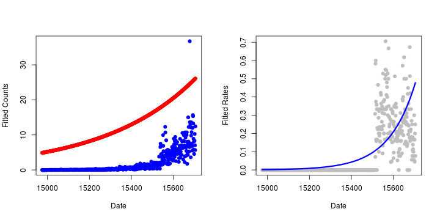

```r
par(mfrow = c(1, 2))
glm2 <- glm(gaData$simplystats ~ julian(gaData$date), offset = log(visits +
    1), family = "poisson", data = gaData)
plot(julian(gaData$date), glm2$fitted, col = "blue", pch = 19, xlab = "Date",
    ylab = "Fitted Counts")
points(julian(gaData$date), glm1$fitted, col = "red", pch = 19)

glm2 <- glm(gaData$simplystats ~ julian(gaData$date), offset = log(visits +
    1), family = "poisson", data = gaData)
plot(julian(gaData$date), gaData$simplystats/(gaData$visits + 1), col = "grey",
    xlab = "Date", ylab = "Fitted Rates", pch = 19)
lines(julian(gaData$date), glm2$fitted/(gaData$visits + 1), col = "blue", lwd = 3)
```

## Further resources

- [Wikipedia on Odds Ratio](http://en.wikipedia.org/wiki/Odds_ratio)
- [Wikipedia on Logistic Regression](http://en.wikipedia.org/wiki/Logistic_regression)
- [Logistic regression and glms in R](http://data.princeton.edu/R/glms.html)
- Brian Caffo's lecture notes on: [Simpson's paradox](http://ocw.jhsph.edu/courses/MethodsInBiostatisticsII/PDFs/lecture23.pdf), [Case-control studies](http://ocw.jhsph.edu/courses/MethodsInBiostatisticsII/PDFs/lecture24.pdf)
- [Open Intro Chapter on Logistic Regression](http://www.openintro.org/stat/down/oiStat2_08.pdf)
- [Log-linear models and multiway tables](http://ww2.coastal.edu/kingw/statistics/R-tutorials/loglin.html)
- [Wikipedia on Poisson regression](http://en.wikipedia.org/wiki/Poisson_regression), [Wikipedia on overdispersion](http://en.wikipedia.org/wiki/Overdispersion)
- [Regression models for count data in R](http://cran.r-project.org/web/packages/pscl/vignettes/countreg.pdf)
- [pscl package](http://cran.r-project.org/web/packages/pscl/index.html) - the function *zeroinfl* fits zero inflated models.

Previous Module. [Module II : Multivariable Regression](http://rpubs.com/sialy/regmod-mod-2)